# 2_model exploration

Leslie Jones

1/7/2020

## Database for Anchor Model

Load data frame from 1_data analysis.Rmd I calculated percent wetland, forest, and shrub riparian cover in GIS by buffering stream by 30m, converted nlcd raster to polygon, used select function to save individual polygon layers of wetland, forest, and shrub. Used Tabulate intersection function to get tables by rca_id or percent overlap and then joined tables to rca shapefile. The covariates are joined individually to the anchor dataframe here. Code also replaces NA with 0 for all 3 covariates.Remove month of April.

### Correlation between LST and air temperature by month

```
## # A tibble: 5 x 2
##   month   cor
##   <dbl> <dbl>
## 1     5 0.602
## 2     6 0.369
## 3     7 0.637
## 4     8 0.459
## 5     9 0.634
```

###correlation between stream temp and air temperature by month

```
## # A tibble: 5 x 2
##   month   cor
##   <dbl> <dbl>
## 1     5 0.818
## 2     6 0.737
## 3     7 0.755
## 4     8 0.569
## 5     9 0.790
```

###correlation and plot between stream temp and LST by month

```
## # A tibble: 5 x 2
##   month     cor
##   <dbl>   <dbl>
## 1     5  0.511
## 2     6  0.111
## 3     7  0.302
## 4     8 -0.0269
## 5     9  0.356
```

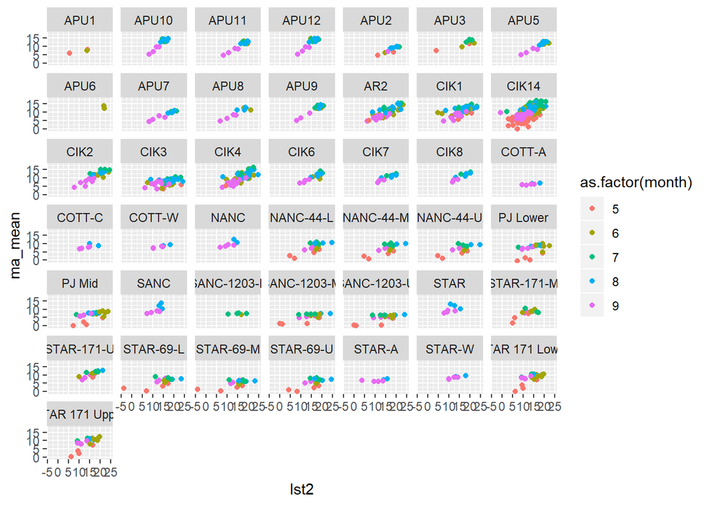

###plot air temperature and LST by month

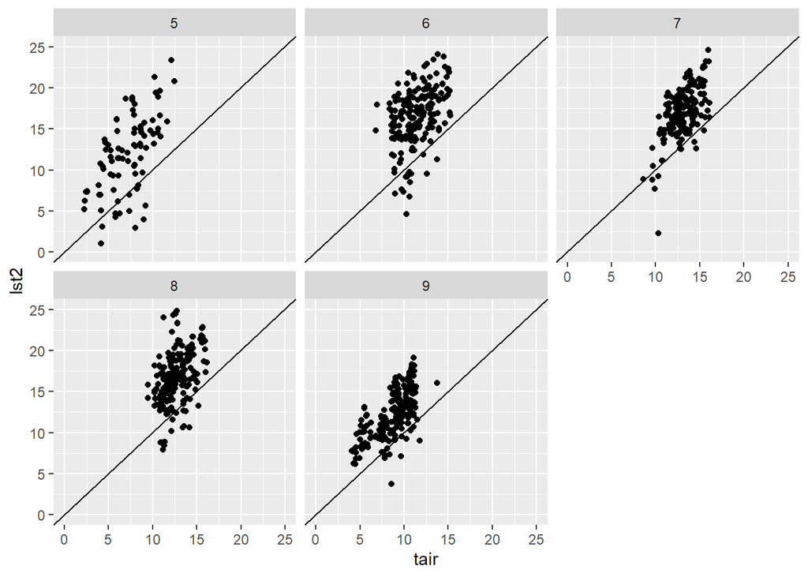

###plot air temperature and stream temperature by month

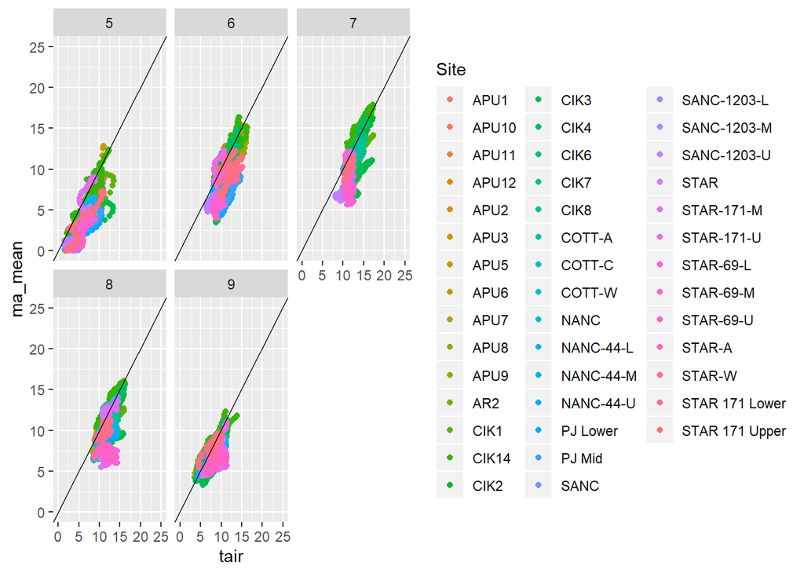

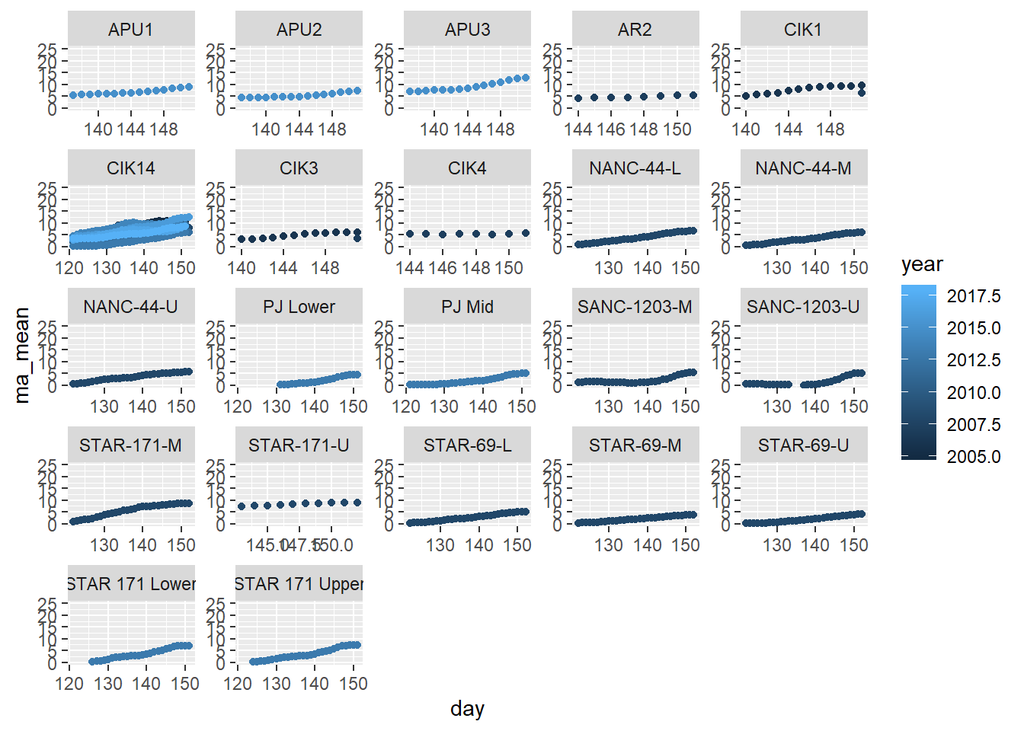

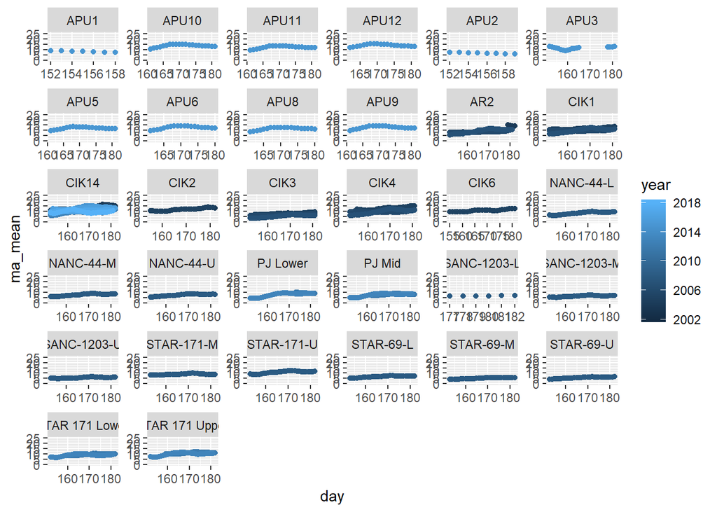

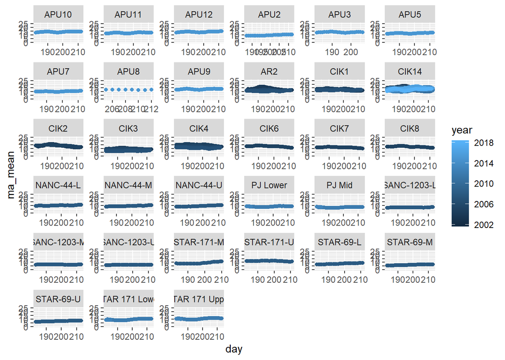

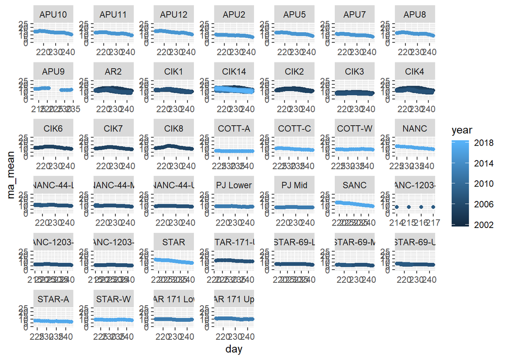

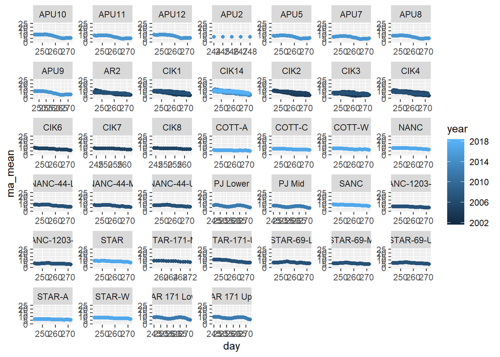

#Remove temperatures less than 0 and calculate temperature index (waterT-airT)/waterT. index approaches 0 then air and stream temp are most similar. From the plots for May you can see that the index approaches 0 for most sites around Julian day 140.

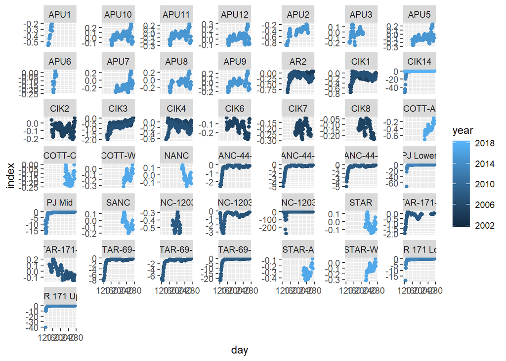

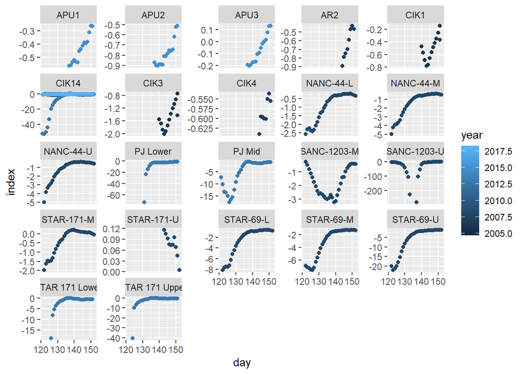

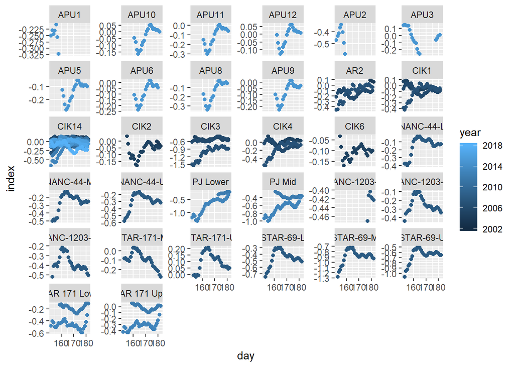

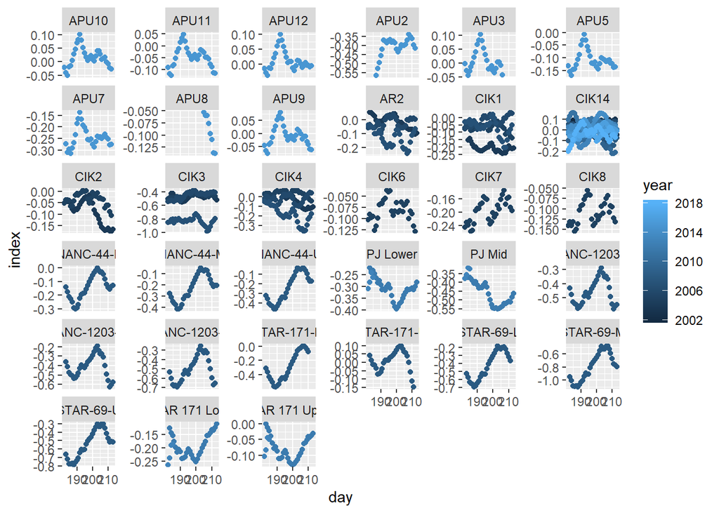

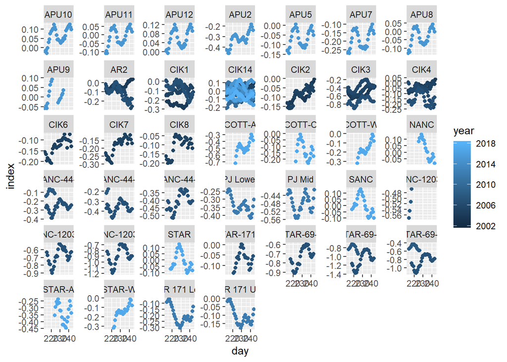

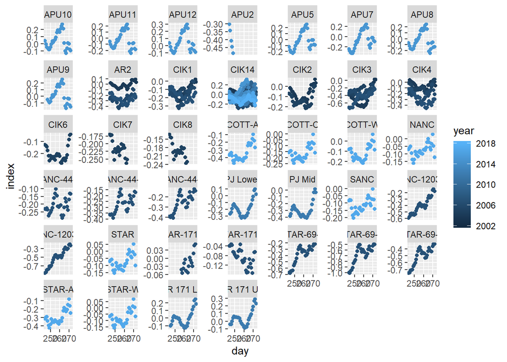

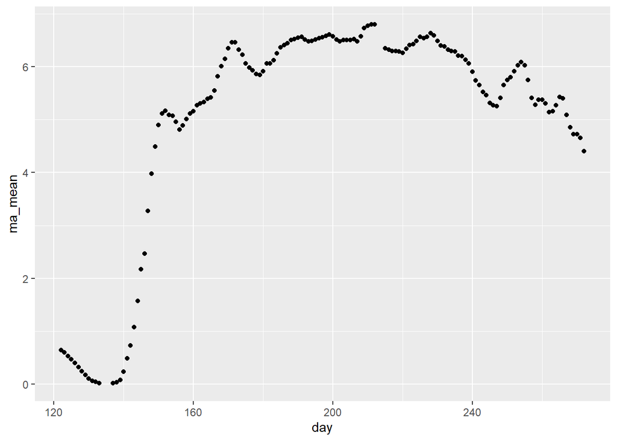

###Remove all data prior to June 1 (Julian Day 152) and replot index

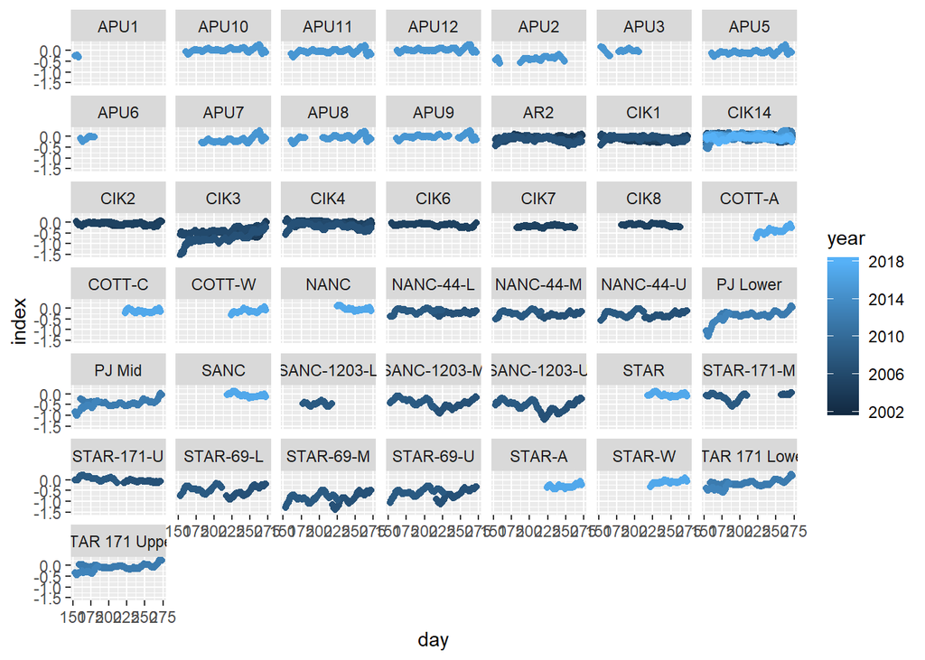

###Look at distribution of covariates to include in model

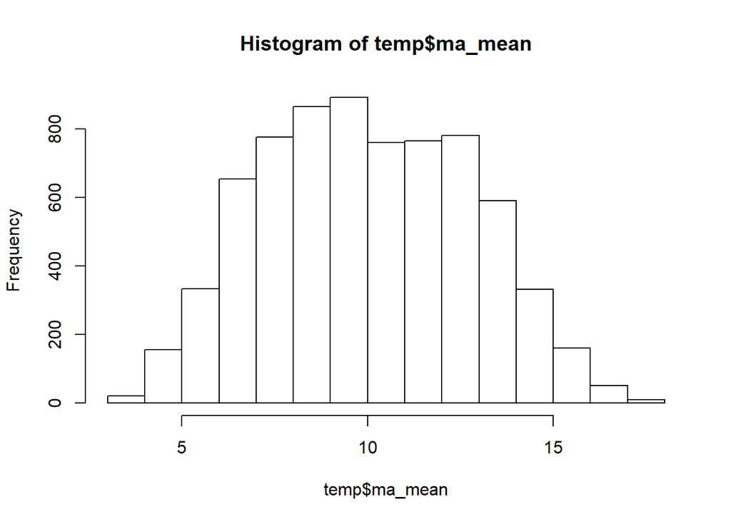

```r
hist(temp$ma_mean)
```

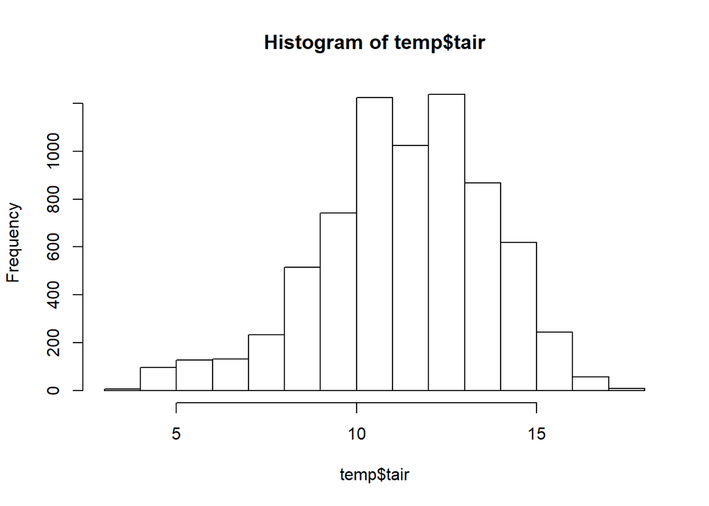

```r
hist(temp$tair)
```

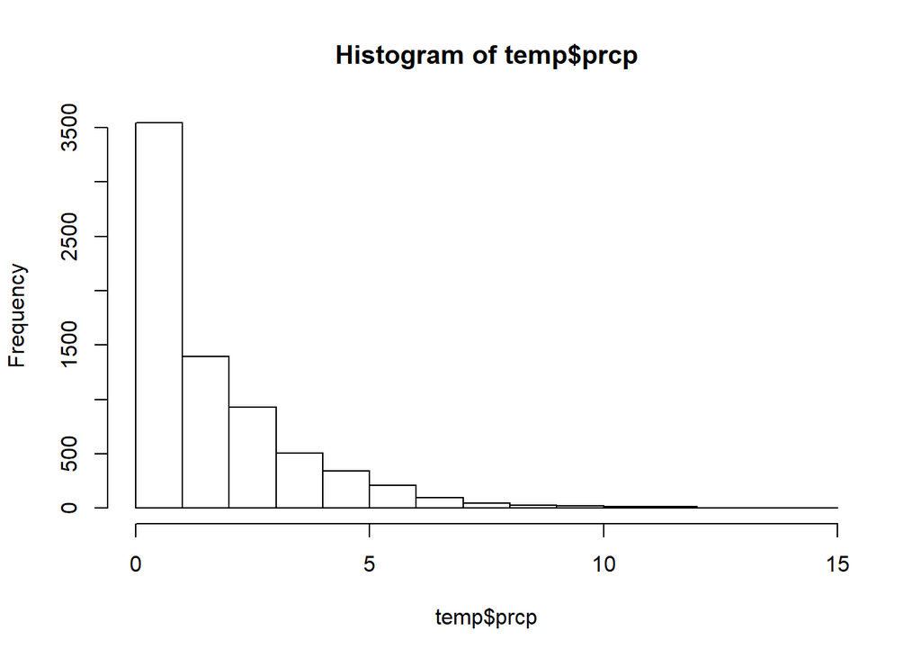

```r
hist(temp$prcp)
```

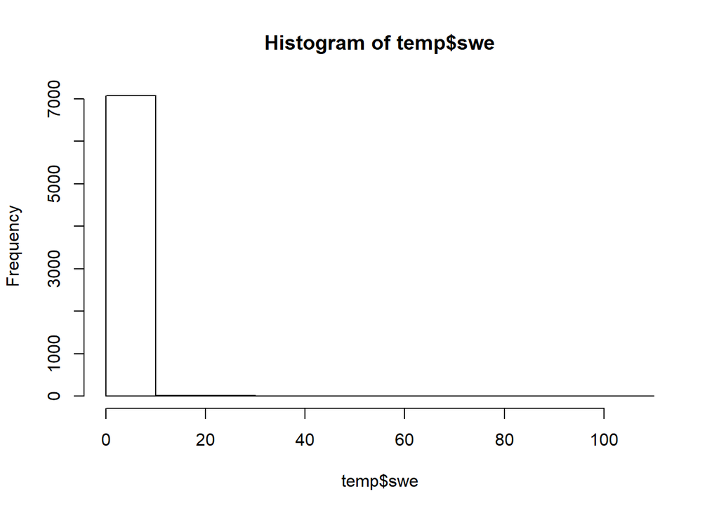

```r
hist(temp$swe)
```

### Modeling

Try out sets of models.

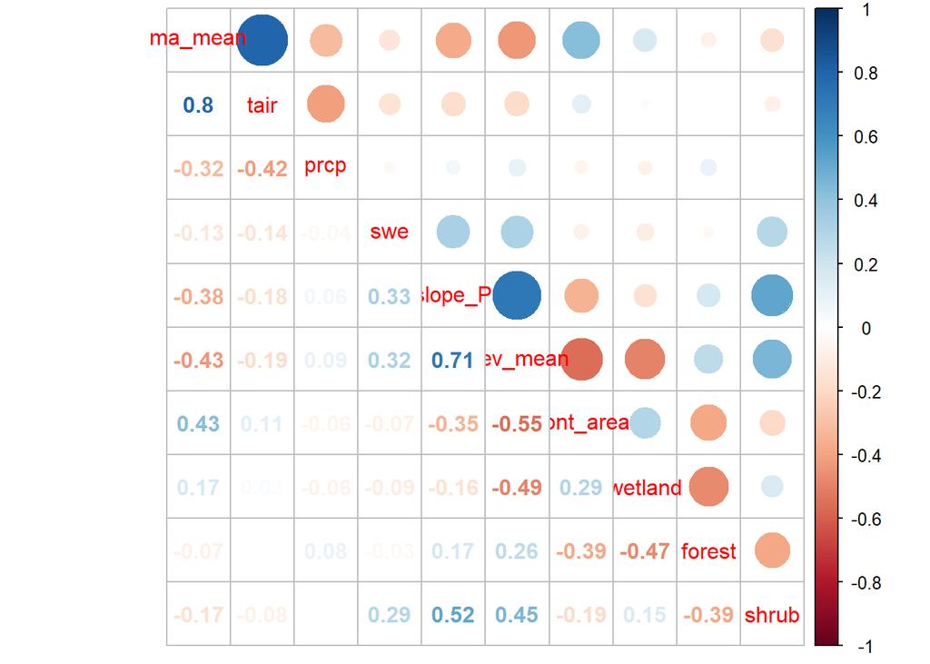

```
## [1] FALSE
```

```
## Fixed term is "(Intercept)"
```

```
## Global model call: lm(formula = ma_mean ~ tair + slope_P + elev_mean + cont_area +
##     month.f + wetland + shrub + forest, data = temp, na.action = "na.fail")
## ---
## Model selection table
##        (Int)  cnt_are   elv_men        frs mnt.f        shr   slp_P    tar
## 256 -0.41060 0.003746 -0.003108  0.0219400     +  0.0324200 -0.6745 0.7614
## 128 -0.14040 0.003699 -0.004378  0.0206800     +  0.0346800 -0.6304 0.7564
## 254 -0.72340 0.003971            0.0218900     +  0.0281700 -0.8066 0.7725
## 248 -1.22400 0.003713 -0.002552  0.0208500        0.0302100 -0.6468 0.8386
## 126 -0.35820 0.004086            0.0186200     +  0.0294800 -0.8320 0.7715
## 246 -1.43800 0.003901            0.0208800        0.0267900 -0.7582 0.8430
## 120 -0.94250 0.003653 -0.004078  0.0192600        0.0328400 -0.5912 0.8362
## 240  0.09858 0.003520 -0.001064  0.0131200     +            -0.4864 0.7841
## 238 -0.04375 0.003615            0.0135300     +            -0.5452 0.7872
## 118 -1.09900 0.004020            0.0174000        0.0280800 -0.7823 0.8433
```

[output cut: 504 more lines]

```
##
## Call:
## lm(formula = ma_mean ~ tair + month.f + slope_P + elev_mean +
##     cont_area + forest + shrub + wetland, data = temp, na.action = "na.fail")
##
## Residuals:
##     Min      1Q  Median      3Q     Max
## -5.3353 -0.7450  0.0900  0.8771  3.9559
##
## Coefficients:
##               Estimate Std. Error t value Pr(>|t|)
## (Intercept) -4.106e-01  1.301e-01  -3.157   0.0016 **
## tair         7.614e-01  9.069e-03  83.958  < 2e-16 ***
## month.f7     4.474e-01  4.650e-02   9.622  < 2e-16 ***
## month.f8     9.252e-02  4.488e-02   2.062   0.0393 *
## month.f9    -3.135e-01  4.955e-02  -6.328 2.64e-10 ***
## slope_P     -6.745e-01  3.082e-02 -21.888  < 2e-16 ***
## elev_mean   -3.108e-03  3.845e-04  -8.082 7.41e-16 ***
## cont_area    3.746e-03  7.827e-05  47.859  < 2e-16 ***
## forest       2.194e-02  8.908e-04  24.624  < 2e-16 ***
## shrub        3.242e-02  1.793e-03  18.086  < 2e-16 ***
## wetland      1.572e-02  2.660e-03   5.911 3.55e-09 ***
## ---
## Signif. codes:  0 '***' 0.001 '**' 0.01 '*' 0.05 '.' 0.1 ' ' 1
##
## Residual standard error: 1.255 on 7130 degrees of freedom
## Multiple R-squared:  0.7959, Adjusted R-squared:  0.7956
## F-statistic:  2781 on 10 and 7130 DF,  p-value: < 2.2e-16
```

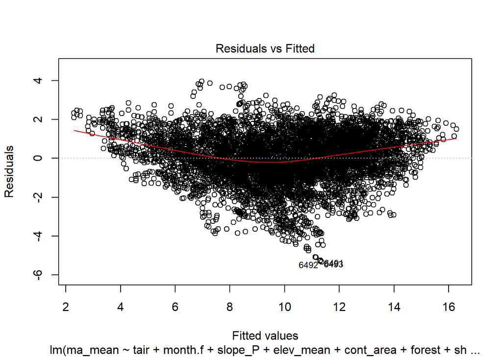

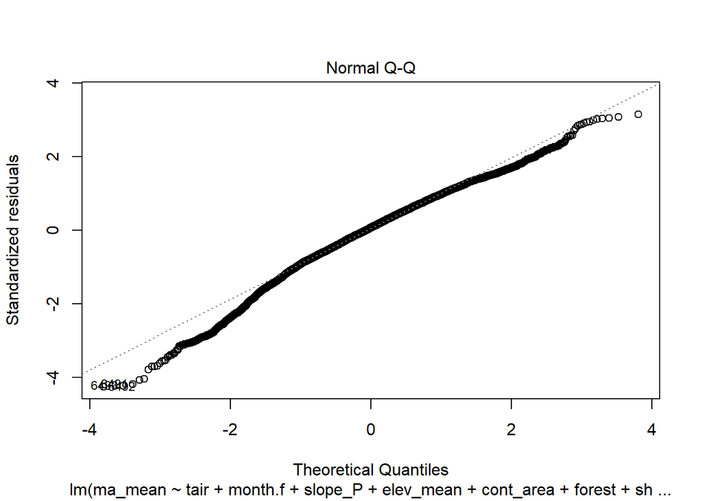

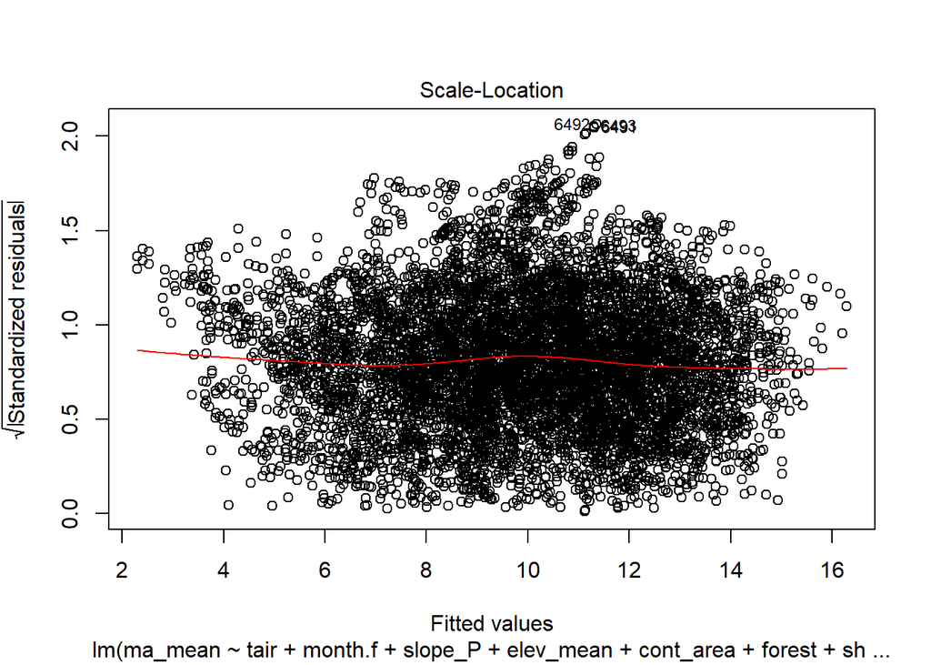

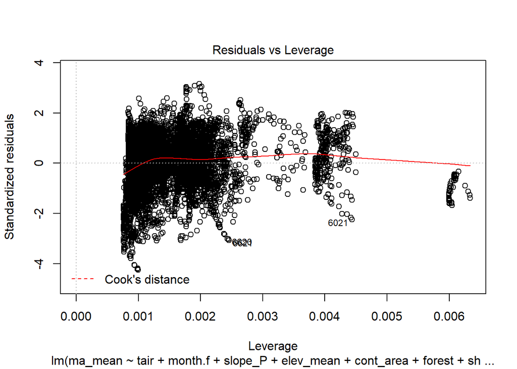

```
## MODEL INFO:
## Observations: 7141
## Dependent Variable: ma_mean
## Type: OLS linear regression
##
## MODEL FIT:
## F(10,7130) = 2780.858, p = 0.000
## R² = 0.796
## Adj. R² = 0.796
##
## Standard errors: OLS
## --------------------------------------------------------------
##                       Est.     2.5%    97.5%    t val.       p
## ----------------- -------- -------- -------- --------- -------
## (Intercept)         -0.411   -0.666   -0.156    -3.157   0.002
## tair                 0.761    0.744    0.779    83.958   0.000
## month.f7             0.447    0.356    0.539     9.622   0.000
## month.f8             0.093    0.005    0.180     2.062   0.039
## month.f9            -0.314   -0.411   -0.216    -6.328   0.000
## slope_P             -0.675   -0.735   -0.614   -21.888   0.000
## elev_mean           -0.003   -0.004   -0.002    -8.082   0.000
## cont_area            0.004    0.004    0.004    47.859   0.000
## forest               0.022    0.020    0.024    24.624   0.000
## shrub                0.032    0.029    0.036    18.086   0.000
## wetland              0.016    0.011    0.021     5.911   0.000
## --------------------------------------------------------------
```

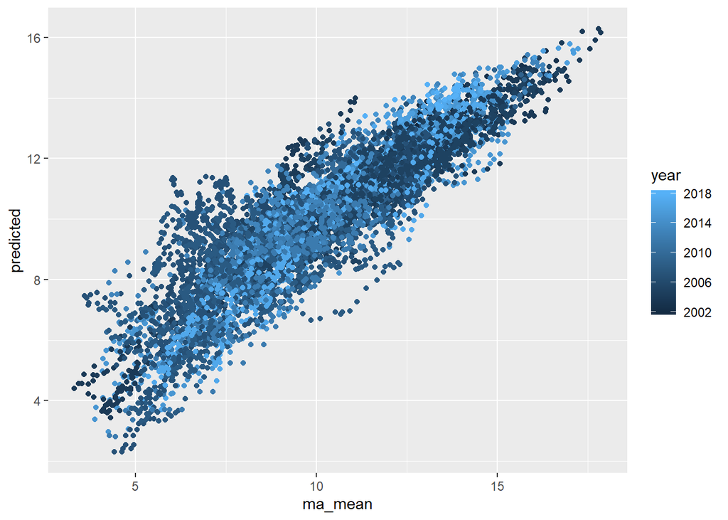

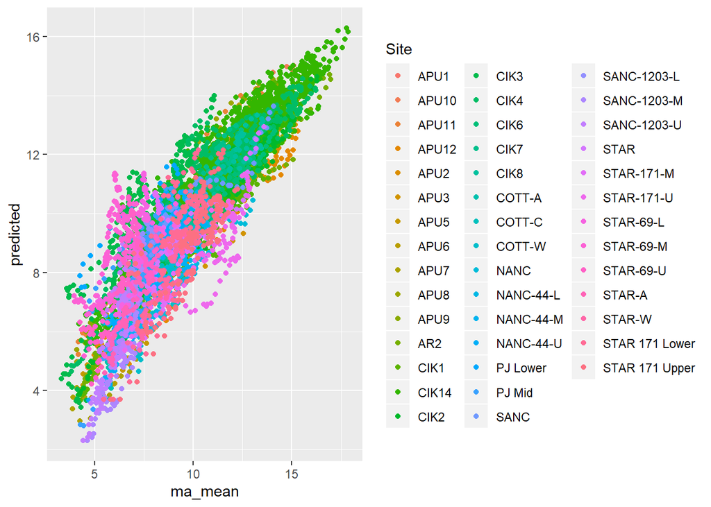

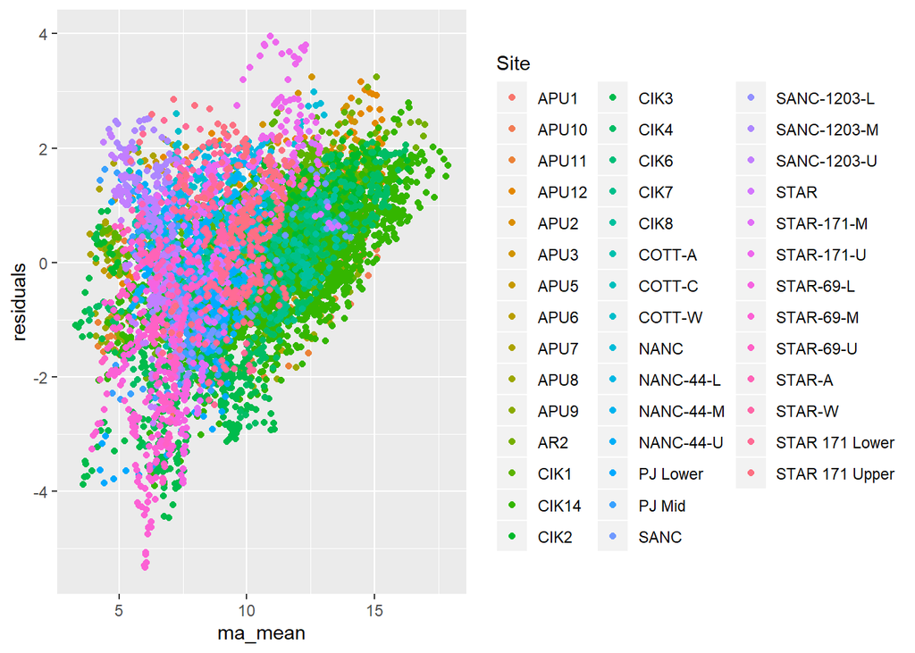

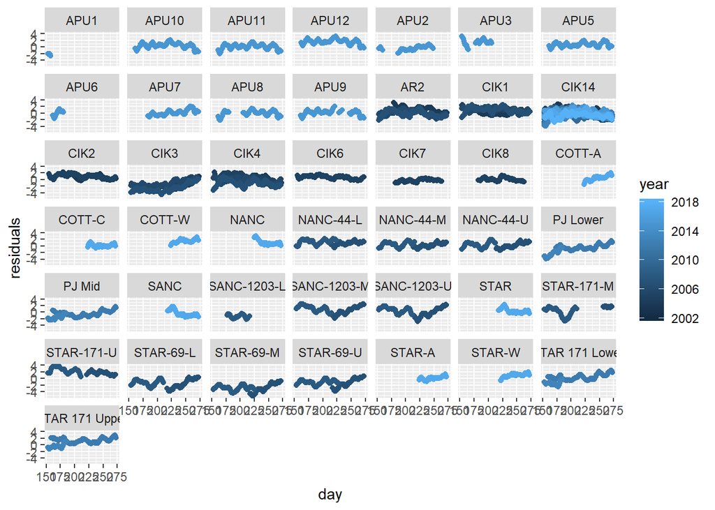

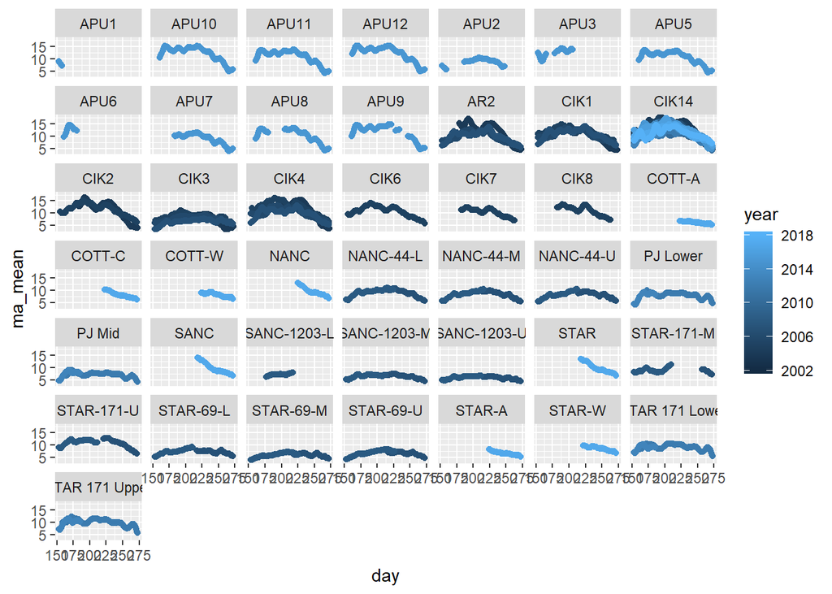

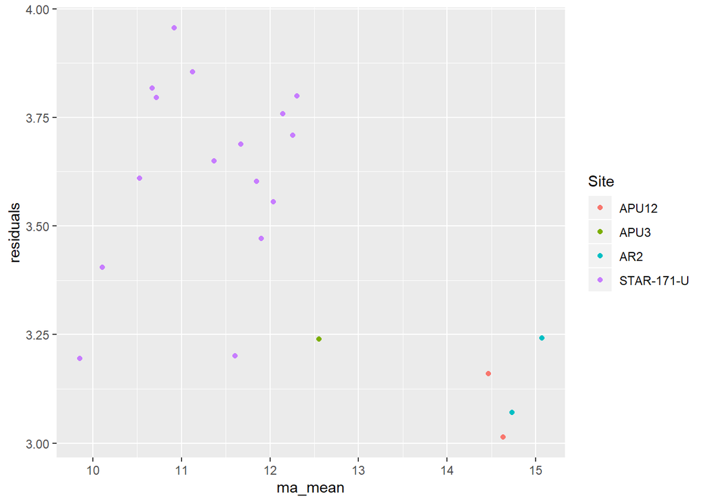

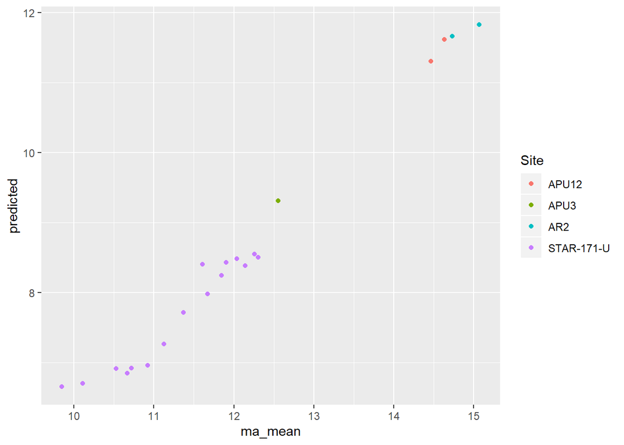

###Investigate model by month to see how coefficients behave June Model

```r
June <- temp %>% filter(month==6)
full.modelJ <- lm(ma_mean ~ tair + slope_P + elev_mean + cont_area + wetland + shrub +forest, data = June,
                na.action = "na.fail")

dredge(full.modelJ)
```

```
## Fixed term is "(Intercept)"
```

```
## Global model call: lm(formula = ma_mean ~ tair + slope_P + elev_mean + cont_area +
##     wetland + shrub + forest, data = June, na.action = "na.fail")
## ---
## Model selection table
##        (Int)  cnt_are    elv_men        frs       shr   slp_P    tar
## 126 -1.30200 0.003753             0.0137600  0.039250 -0.7807 0.8398
## 128 -1.46600 0.003847  0.0015690  0.0137900  0.036670 -0.8442 0.8470
## 62  -1.23000 0.003733             0.0115300  0.038930 -0.7784 0.8524
## 64  -1.18300 0.003702 -0.0005738  0.0119000  0.039930 -0.7556 0.8475
## 58  -0.98680 0.003306                        0.027380 -0.6456 0.8919
## 60  -1.03500 0.003345  0.0004966             0.026840 -0.6691 0.8950
## 122 -0.99130 0.003295                        0.027020 -0.6412 0.8910
## 124 -1.14800 0.003384  0.0015010             0.024520 -0.7016 0.8981
## 120 -1.11500 0.003728  0.0057230  0.0039600           -0.7404 0.8825
## 116 -1.03900 0.003569  0.0051800                      -0.6997 0.8973
```

[output cut: 248 more lines]

```r
chosen.modelJ <- lm(ma_mean ~ tair + slope_P + elev_mean + cont_area + forest + shrub + wetland  , data = June,
                na.action = "na.fail")
summary(chosen.modelJ)
```

```
##
## Call:
## lm(formula = ma_mean ~ tair + slope_P + elev_mean + cont_area +
##     forest + shrub + wetland, data = June, na.action = "na.fail")
##
## Residuals:
##     Min      1Q  Median      3Q     Max
## -3.8121 -0.9420  0.1793  0.9411  4.1009
##
## Coefficients:
##               Estimate Std. Error t value Pr(>|t|)
## (Intercept) -1.4661695  0.2919474  -5.022 5.73e-07 ***
## tair         0.8470230  0.0226311  37.427  < 2e-16 ***
## slope_P     -0.8441613  0.0781551 -10.801  < 2e-16 ***
## elev_mean    0.0015690  0.0011908   1.318  0.18782
## cont_area    0.0038468  0.0001929  19.942  < 2e-16 ***
## forest       0.0137904  0.0025042   5.507 4.30e-08 ***
## shrub        0.0366671  0.0045381   8.080 1.34e-15 ***
## wetland      0.0183992  0.0067952   2.708  0.00685 **
## ---
## Signif. codes:  0 '***' 0.001 '**' 0.01 '*' 0.05 '.' 0.1 ' ' 1
##
## Residual standard error: 1.408 on 1478 degrees of freedom
## Multiple R-squared:  0.7093, Adjusted R-squared:  0.7079
## F-statistic: 515.2 on 7 and 1478 DF,  p-value: < 2.2e-16
```

###Investigate model by month to see how coefficients behave July Model

```r
July <- temp %>% filter(month==7)
full.modelJY <- lm(ma_mean ~ tair + slope_P + elev_mean + cont_area + wetland + shrub +forest, data = July,
                na.action = "na.fail")

dredge(full.modelJY)
```

```
## Fixed term is "(Intercept)"
```

```
## Global model call: lm(formula = ma_mean ~ tair + slope_P + elev_mean + cont_area +
##     wetland + shrub + forest, data = July, na.action = "na.fail")
## ---
## Model selection table
##       (Int)  cnt_are    elv_men        frs        shr   slp_P    tar
## 128 -1.6410 0.004587 -0.0034650  0.0242400  0.0342100 -0.6370 0.8666
## 64  -1.2330 0.004552 -0.0048130  0.0232000  0.0379200 -0.6050 0.8488
## 126 -2.0620 0.004799             0.0234200  0.0269800 -0.7570 0.8892
## 62  -1.4600 0.004914             0.0200600  0.0291900 -0.7933 0.8670
## 118 -1.7890 0.004382             0.0148300            -0.4701 0.9318
## 120 -1.7070 0.004328 -0.0005751  0.0145900            -0.4374 0.9299
## 112 -2.2130 0.004241 -0.0066920  0.0175100  0.0207800         0.9441
## 48  -1.9800 0.004231 -0.0073270  0.0171400  0.0231300         0.9325
## 56  -0.9048 0.004200 -0.0026470  0.0104100            -0.3300 0.9080
## 104 -2.1350 0.004137 -0.0039910  0.0122800                    0.9711
```

[output cut: 248 more lines]

```r
chosen.modelJY <- lm(ma_mean ~ tair + slope_P + elev_mean + cont_area + forest + shrub + wetland  , data = July,
                na.action = "na.fail")
summary(chosen.modelJY)
```

```
##
## Call:
## lm(formula = ma_mean ~ tair + slope_P + elev_mean + cont_area +
##     forest + shrub + wetland, data = July, na.action = "na.fail")
##
## Residuals:
##     Min      1Q  Median      3Q     Max
## -4.3771 -0.6766  0.0139  0.9538  3.3497
##
## Coefficients:
##               Estimate Std. Error t value Pr(>|t|)
## (Intercept) -1.6412518  0.3349391  -4.900 1.04e-06 ***
## tair         0.8666397  0.0245577  35.290  < 2e-16 ***
## slope_P     -0.6369944  0.0658293  -9.676  < 2e-16 ***
## elev_mean   -0.0034648  0.0007961  -4.352 1.42e-05 ***
## cont_area    0.0045875  0.0001620  28.319  < 2e-16 ***
## forest       0.0242415  0.0019183  12.637  < 2e-16 ***
## shrub        0.0342100  0.0039577   8.644  < 2e-16 ***
## wetland      0.0151948  0.0048410   3.139  0.00172 **
## ---
## Signif. codes:  0 '***' 0.001 '**' 0.01 '*' 0.05 '.' 0.1 ' ' 1
##
## Residual standard error: 1.273 on 1840 degrees of freedom
## Multiple R-squared:  0.7613, Adjusted R-squared:  0.7604
## F-statistic: 838.3 on 7 and 1840 DF,  p-value: < 2.2e-16
```

###Investigate model by month to see how coefficients behave August Model

```r
August <- temp %>% filter(month==8)
full.modelA <- lm(ma_mean ~ tair + slope_P + elev_mean + cont_area + wetland + shrub +forest, data = August,
                na.action = "na.fail")

dredge(full.modelA)
```

```
## Fixed term is "(Intercept)"
```

```
## Global model call: lm(formula = ma_mean ~ tair + slope_P + elev_mean + cont_area +
##     wetland + shrub + forest, data = August, na.action = "na.fail")
## ---
## Model selection table
##       (Int)  cnt_are   elv_men       frs        shr   slp_P    tar
## 128  0.0717 0.004528 -0.005516  0.033110  4.647e-02 -1.0020 0.6999
## 64   0.2092 0.004531 -0.006095  0.032620  4.766e-02 -0.9854 0.6963
## 126 -0.5868 0.004932            0.033050  3.999e-02 -1.2330 0.7202
## 62  -0.2141 0.005183            0.030320  4.279e-02 -1.2780 0.7121
## 120  0.7230 0.004131 -0.003110  0.021130            -0.7055 0.7362
## 118  0.2732 0.004407            0.022090            -0.8694 0.7454
## 56   1.2400 0.004109 -0.004844  0.018440            -0.6257 0.7272
## 54   0.8108 0.004674            0.017750            -0.8928 0.7375
## 112  0.4495 0.004081 -0.011780  0.024400  2.492e-02         0.7316
## 48   0.2946 0.004068 -0.011210  0.024820  2.310e-02         0.7365
```

[output cut: 248 more lines]

```r
chosen.modelA <- lm(ma_mean ~ tair + slope_P + elev_mean + cont_area + forest + shrub + wetland  , data = August,
                na.action = "na.fail")
summary(chosen.modelA)
```

```
##
## Call:
## lm(formula = ma_mean ~ tair + slope_P + elev_mean + cont_area +
##     forest + shrub + wetland, data = August, na.action = "na.fail")
##
## Residuals:
##     Min      1Q  Median      3Q     Max
## -4.9254 -0.5838  0.1301  0.8185  2.9179
##
## Coefficients:
##               Estimate Std. Error t value Pr(>|t|)
## (Intercept)  0.0716967  0.2743568   0.261    0.794
## tair         0.6998778  0.0185566  37.716  < 2e-16 ***
## slope_P     -1.0016134  0.0561733 -17.831  < 2e-16 ***
## elev_mean   -0.0055162  0.0006853  -8.049 1.43e-15 ***
## cont_area    0.0045275  0.0001464  30.930  < 2e-16 ***
## forest       0.0331149  0.0015689  21.107  < 2e-16 ***
## shrub        0.0464715  0.0032644  14.236  < 2e-16 ***
## wetland      0.0084652  0.0054614   1.550    0.121
## ---
## Signif. codes:  0 '***' 0.001 '**' 0.01 '*' 0.05 '.' 0.1 ' ' 1
##
## Residual standard error: 1.218 on 1965 degrees of freedom
## Multiple R-squared:  0.7233, Adjusted R-squared:  0.7224
## F-statistic: 733.9 on 7 and 1965 DF,  p-value: < 2.2e-16
```

###Investigate model by month to see how coefficients behave September Model

```r
Sept <- temp %>% filter(month==9)
full.modelS <- lm(ma_mean ~ tair + slope_P + elev_mean + cont_area + wetland + shrub +forest, data = Sept,
                na.action = "na.fail")

dredge(full.modelS)
```

```
## Fixed term is "(Intercept)"
```

```
## Global model call: lm(formula = ma_mean ~ tair + slope_P + elev_mean + cont_area +
##     wetland + shrub + forest, data = Sept, na.action = "na.fail")
## ---
## Model selection table
##      (Int)   cnt_are   elv_men        frs        shr     slp_P    tar
## 128 1.2160 0.0013970 -0.002827  0.0072770  4.229e-03 -0.161400 0.6700
## 120 1.3240 0.0013570 -0.002690  0.0060650            -0.130200 0.6708
## 104 1.3380 0.0013230 -0.003826  0.0058130                      0.6726
## 112 1.3270 0.0013270 -0.003870  0.0059370  4.552e-04           0.6726
## 118 1.0330 0.0015930            0.0067750            -0.277900 0.6717
## 126 0.9727 0.0016180            0.0073890  2.078e-03 -0.296900 0.6714
## 124 1.8190 0.0011670 -0.002874            -3.805e-03 -0.088020 0.6616
## 116 1.8080 0.0011690 -0.003064                       -0.113000 0.6588
## 108 1.8190 0.0011500 -0.003489            -5.170e-03           0.6641
## 100 1.8030 0.0011470 -0.004041                                 0.6608
```

[output cut: 248 more lines]

```r
chosen.modelS <- lm(ma_mean ~ tair + slope_P + elev_mean + cont_area + forest + shrub + wetland  , data = Sept,
                na.action = "na.fail")
summary(chosen.modelS)
```

```
##
## Call:
## lm(formula = ma_mean ~ tair + slope_P + elev_mean + cont_area +
##     forest + shrub + wetland, data = Sept, na.action = "na.fail")
##
## Residuals:
##     Min      1Q  Median      3Q     Max
## -3.4515 -0.4551  0.0270  0.5098  2.3926
##
## Coefficients:
##               Estimate Std. Error t value Pr(>|t|)
## (Intercept)  1.216e+00  1.391e-01   8.744  < 2e-16 ***
## tair         6.700e-01  1.002e-02  66.880  < 2e-16 ***
## slope_P     -1.614e-01  3.866e-02  -4.176 3.11e-05 ***
## elev_mean   -2.827e-03  4.488e-04  -6.298 3.76e-10 ***
## cont_area    1.397e-03  9.987e-05  13.991  < 2e-16 ***
## forest       7.277e-03  1.109e-03   6.562 6.89e-11 ***
## shrub        4.229e-03  2.176e-03   1.943   0.0521 .
## wetland      3.415e-02  3.652e-03   9.352  < 2e-16 ***
## ---
## Signif. codes:  0 '***' 0.001 '**' 0.01 '*' 0.05 '.' 0.1 ' ' 1
##
## Residual standard error: 0.7964 on 1826 degrees of freedom
## Multiple R-squared:  0.771,  Adjusted R-squared:  0.7701
## F-statistic: 878.2 on 7 and 1826 DF,  p-value: < 2.2e-16
```